# quick_simulation_res

2025-02-18

## Simulation Summary

We investigate the “CpG” mapping performance of different methods.

### Simulation Procedure

1. Simulate a univariate covariate $X$ from a $N(0,1)$ distribution with $N = 100$ or $200$.
2. Simulate $2^S$ CpGs (64 or 128), where 5 or 10 CpGs are affected by $X$.
3. $X$ affects all CpGs in a similar fashion with $h^2 = 1\%$, $5\%$, or $10\%$.

Below, we evaluate the performance of different methods based on:

1. **Univariate p-values**: One p-value per CpG-$X$ association test.
2. **Local False Sign Rate (LFSR) from HMM regression**: One LFSR value per CpG-$X$ association.
3. **Z-score from wavelet regression**: Defined as the ratio of the wavelet function estimate at a given CpG to the width of the 95% credible interval.

## Remarks / Results

# total number of CPGs=64

### N=100 simulations

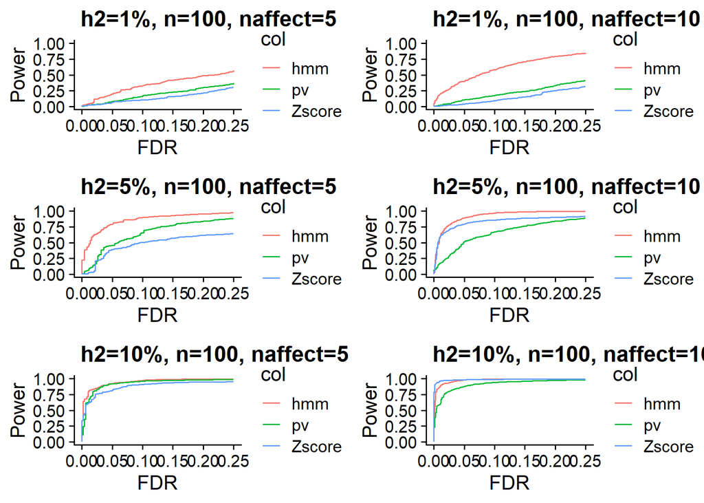

### N=200 simulations

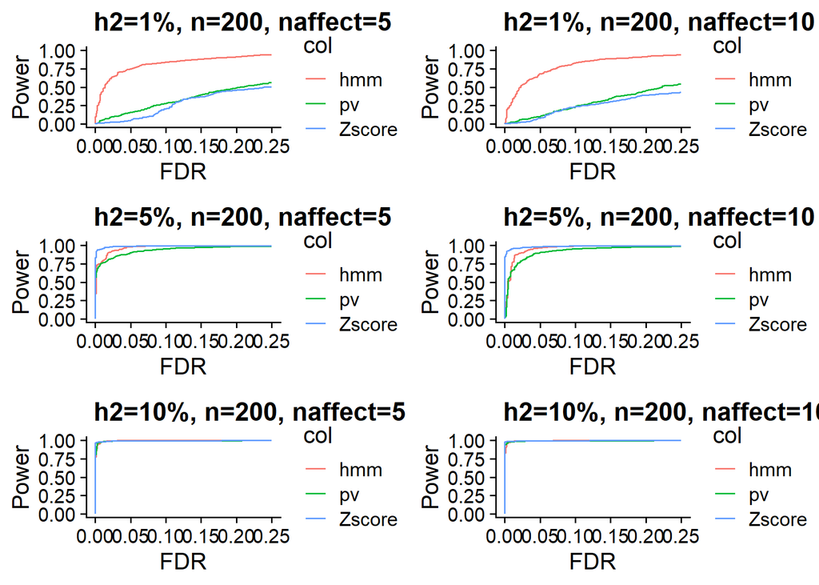

# total number of CPGs=128

### N=100 simulations

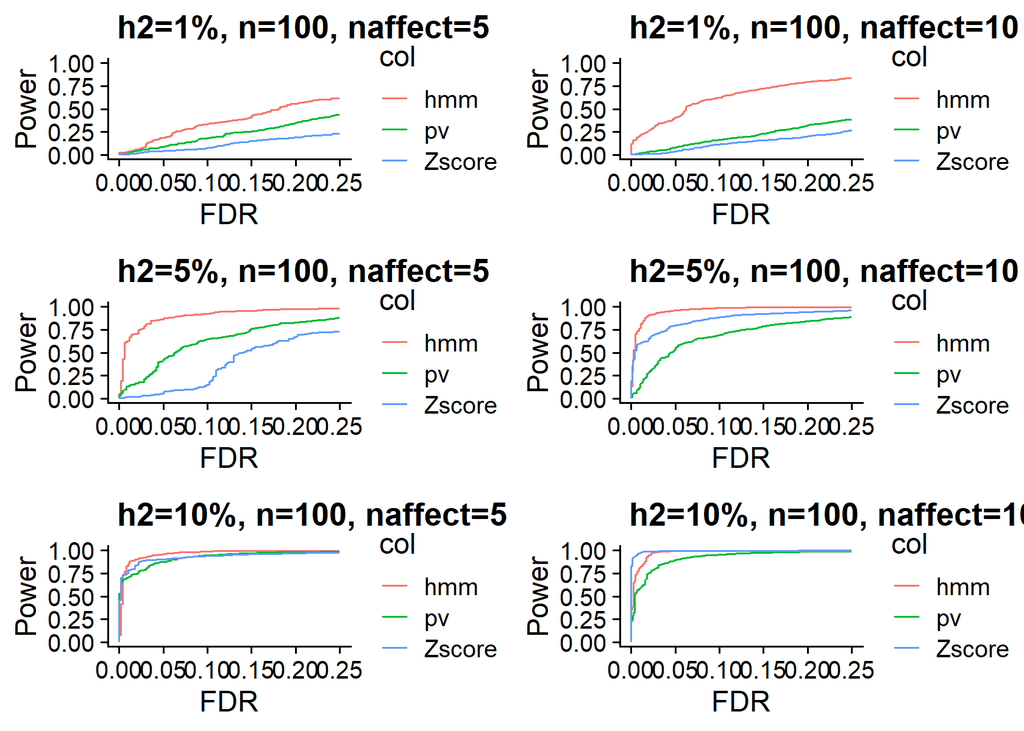

### N=200 simulations

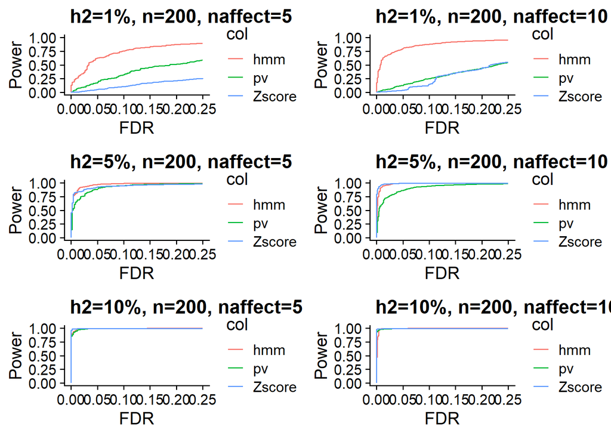